# GAE2

Author

## GAE2:

Data summary and communication:

1. Measure the maximum dimension of 20 red beans and 20 white beans.
2. Create an appropriately formatted .csv file for import to R
3. Summarize your data using measures of location (mean and median) and of dispersion (standard deviation, range, IQR).
4. Create a table and a figure communicating the data summary.

## Tom’s Example:

### Methods:

#### Statistical Methods:

I summarized the maximum lengths using functions provided in *R* (R Core Team 2023). I used functions provided by the *tidyverse* metapackage (Wickham et al. 2019) for data manipulation and plotting and from *knitr* and *kableExtra* (Xie 2023, Zhu 2024) for table formatting.

### Results:

Bean length overlapped for the two varieties, but baby Lima bean length averaged approximately 2 mm longer than that for the red kidney beans (Table 1, Figure 1). It’s interesting to note that while the standard deviation and range was greater for the baby Lima beans, the interquartile range was narrower.

Table 1: Summary of maximum dimensions (lengths) of red kidney beans and baby Lima beans measured to the nearest 0.1 mm.

| Bean | Mean | Median | Standard Deviation | Range | IQR |
| --- | --- | --- | --- | --- | --- |
| Red Kidney | 12.9 | 12.8 | 1.1 | 3.5 | 1.6 |
| Baby Lima | 15.1 | 15.3 | 1.3 | 5.0 | 1.0 |

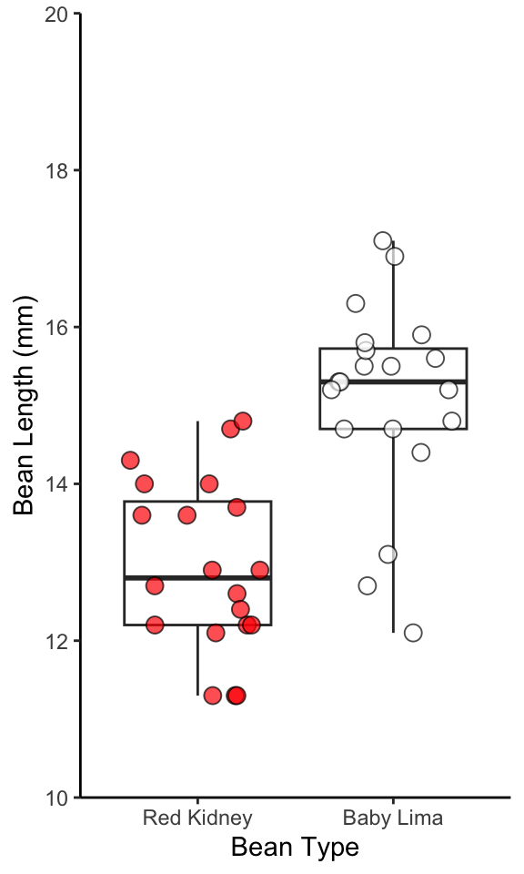

## References:

R Core Team. 2023. [R: A language and environment for statistical computing](https://www.R-project.org/). R Foundation for Statistical Computing, Vienna, Austria.

Wickham, H., M. Averick, J. Bryan, W. Chang, L. D. McGowan, R. François, G. Grolemund, A. Hayes, L. Henry, J. Hester, M. Kuhn, T. L. Pedersen, E. Miller, S. M. Bache, K. Müller, J. Ooms, D. Robinson, D. P. Seidel, V. Spinu, K. Takahashi, D. Vaughan, C. Wilke, K. Woo, and H. Yutani. 2019. [Welcome to the tidyverse](https://doi.org/10.21105/joss.01686) 4:1686.

Xie, Y. 2023. [Knitr: A general-purpose package for dynamic report generation in r](https://yihui.org/knitr/).

Zhu, H. 2024. [kableExtra: Construct complex table with ’kable’ and pipe syntax](https://CRAN.R-project.org/package=kableExtra).